# Lab 8: Hyperparameter Tuning

Author

Hanna Velicer

# Set Up (Data Import/Tidy/Transform)

```r
# Loading libraries
library(dplyr)
library(tidyverse)
library(tidymodels)
library(glue)
library(powerjoin)
library(ggplot2)
library(patchwork)

# Reading in the data
root  <- 'https://gdex.ucar.edu/dataset/camels/file'

download.file('https://gdex.ucar.edu/dataset/camels/file/camels_attributes_v2.0.pdf', 'data/camels_attributes_v2.0.pdf')

types <- c("clim", "geol", "soil", "topo", "vege", "hydro")

remote_files  <- glue('{root}/camels_{types}.txt')

local_files   <- glue('data/camels_{types}.txt')

walk2(remote_files, local_files, download.file, quiet = TRUE)

# Cleaning the data
camels <- map(local_files, read_delim, show_col_types = FALSE)
camels <- power_full_join(camels ,by = 'gauge_id')

summary(camels)
```

```
   gauge_id             p_mean          pet_mean     p_seasonality
 Length:671         Min.   :0.6446   Min.   :1.899   Min.   :-1.43546
 Class :character   1st Qu.:2.3731   1st Qu.:2.335   1st Qu.:-0.26352
 Mode  :character   Median :3.2295   Median :2.688   Median : 0.08093
                    Mean   :3.2577   Mean   :2.787   Mean   :-0.04128
                    3rd Qu.:3.7835   3rd Qu.:3.146   3rd Qu.: 0.22399
                    Max.   :8.9369   Max.   :4.744   Max.   : 0.92202

   frac_snow          aridity       high_prec_freq  high_prec_dur
 Min.   :0.00000   Min.   :0.2203   Min.   : 7.90   Min.   :1.075
 1st Qu.:0.03514   1st Qu.:0.6957   1st Qu.:18.50   1st Qu.:1.209
 Median :0.09793   Median :0.8551   Median :22.00   Median :1.282
 Mean   :0.17760   Mean   :1.0565   Mean   :20.93   Mean   :1.350
 3rd Qu.:0.22306   3rd Qu.:1.2673   3rd Qu.:24.23   3rd Qu.:1.440
 Max.   :0.90633   Max.   :5.2079   Max.   :32.70   Max.   :2.091

 high_prec_timing   low_prec_freq    low_prec_dur    low_prec_timing
 Length:671         Min.   :169.9   Min.   : 2.789   Length:671
 Class :character   1st Qu.:232.7   1st Qu.: 4.241   Class :character
 Mode  :character   Median :255.8   Median : 4.950   Mode  :character
                    Mean   :254.6   Mean   : 5.954
                    3rd Qu.:278.9   3rd Qu.: 6.702
                    Max.   :348.7   Max.   :36.513

 geol_1st_class     glim_1st_class_frac geol_2nd_class     glim_2nd_class_frac
 Length:671         Min.   :0.2967      Length:671         Min.   :0.000000
 Class :character   1st Qu.:0.6083      Class :character   1st Qu.:0.002894
 Mode  :character   Median :0.8294      Mode  :character   Median :0.136540
                    Mean   :0.7855                         Mean   :0.155426
                    3rd Qu.:0.9971                         3rd Qu.:0.266373
                    Max.   :1.0000                         Max.   :0.489930

 carbonate_rocks_frac geol_porostiy     geol_permeability soil_depth_pelletier
 Min.   :0.00000      Min.   :0.01000   Min.   :-16.50    Min.   : 0.2667
 1st Qu.:0.00000      1st Qu.:0.06767   1st Qu.:-14.77    1st Qu.: 1.0000
 Median :0.00000      Median :0.13190   Median :-13.96    Median : 1.2283
 Mean   :0.11874      Mean   :0.12637   Mean   :-13.89    Mean   :10.8728
 3rd Qu.:0.04333      3rd Qu.:0.18623   3rd Qu.:-13.00    3rd Qu.:12.8894
 Max.   :1.00000      Max.   :0.28000   Max.   :-10.90    Max.   :50.0000
                      NA's   :3
```

[output cut: 65 more lines]

```
 Min.   :  0.000   Min.   : 0.000   Min.   :  0.00   Min.   :  0.00
 1st Qu.:  6.412   1st Qu.: 1.821   1st Qu.: 37.44   1st Qu.: 10.00
 Median : 15.100   Median : 2.848   Median : 96.00   Median : 15.52
 Mean   : 25.745   Mean   : 6.913   Mean   :107.62   Mean   : 22.28
 3rd Qu.: 35.788   3rd Qu.: 7.554   3rd Qu.:162.14   3rd Qu.: 26.91
 Max.   :172.800   Max.   :92.559   Max.   :356.80   Max.   :209.88
 NA's   :1         NA's   :1        NA's   :1        NA's   :1
  zero_q_freq         hfd_mean
 Min.   :0.00000   Min.   :112.2
 1st Qu.:0.00000   1st Qu.:160.2
 Median :0.00000   Median :173.8
 Mean   :0.03415   Mean   :182.5
 3rd Qu.:0.00000   3rd Qu.:204.1
 Max.   :0.96537   Max.   :287.8
 NA's   :1         NA's   :1
```

```r
ls(camels)
```

```
 [1] "area_gages2"          "area_geospa_fabric"   "aridity"
 [4] "baseflow_index"       "carbonate_rocks_frac" "clay_frac"
 [7] "dom_land_cover"       "dom_land_cover_frac"  "elev_mean"
[10] "frac_forest"          "frac_snow"            "gauge_id"
[13] "gauge_lat"            "gauge_lon"            "geol_1st_class"
[16] "geol_2nd_class"       "geol_permeability"    "geol_porostiy"
[19] "glim_1st_class_frac"  "glim_2nd_class_frac"  "gvf_diff"
[22] "gvf_max"              "hfd_mean"             "high_prec_dur"
[25] "high_prec_freq"       "high_prec_timing"     "high_q_dur"
[28] "high_q_freq"          "lai_diff"             "lai_max"
[31] "low_prec_dur"         "low_prec_freq"        "low_prec_timing"
[34] "low_q_dur"            "low_q_freq"           "max_water_content"
[37] "organic_frac"         "other_frac"           "p_mean"
[40] "p_seasonality"        "pet_mean"             "q_mean"
[43] "q5"                   "q95"                  "root_depth_50"
[46] "root_depth_99"        "runoff_ratio"         "sand_frac"
[49] "silt_frac"            "slope_fdc"            "slope_mean"
[52] "soil_conductivity"    "soil_depth_pelletier" "soil_depth_statsgo"
[55] "soil_porosity"        "stream_elas"          "water_frac"
[58] "zero_q_freq"
```

```r
camels <- na.omit(camels)
```

# Data Splitting

```r
set.seed(123)

camels <- camels %>%
  mutate(logQmean = log(q_mean))

camels_split <- initial_split(camels, prop = 0.8)
camels_train <- training(camels_split)
camels_test  <- testing(camels_split)
```

# Feature Engineering

```r
# Recipe
rec <-  recipe(logQmean ~ aridity + p_mean, data = camels_train) %>%
  step_log(all_predictors()) %>%
  step_interact(terms = ~ aridity:p_mean) %>%
  step_naomit(all_predictors(), all_outcomes())
```

# Resampling and Model Testing

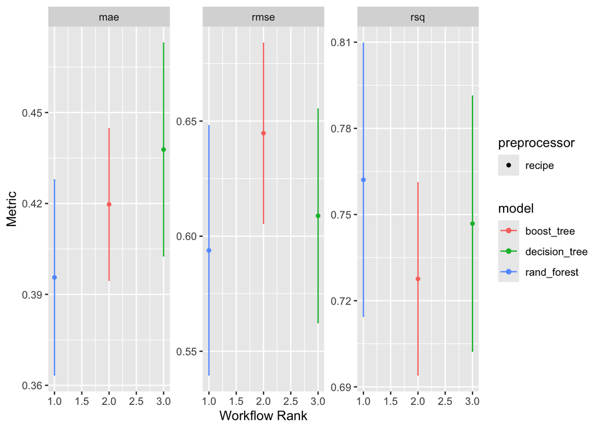

```r
# Build resamples
camels_cv <- vfold_cv(camels_train, v = 10)

# Build 3 candidate models
xgb_mod <- boost_tree() %>%
  set_engine("xgboost") %>%
  set_mode("regression")

dt_mod <- decision_tree() %>%
  set_engine("rpart") %>%
  set_mode("regression")

rf_mod <- rand_forest() %>%
  set_engine("ranger") %>%
  set_mode("regression")

# Test the models
wf <- workflow_set(list(rec), list(boost  = xgb_mod,
                                  dt       = dt_mod,
                                  ranger   = rf_mod)) %>%
  workflow_map(resamples = camels_cv,
               metrics   = metric_set(mae, rsq, rmse))

autoplot(wf)
```

```r
rank_results(wf, rank_metric = "rsq", select_best = TRUE)
```

```
# A tibble: 9 × 9
  wflow_id      .config     .metric  mean std_err     n preprocessor model  rank
  <chr>         <chr>       <chr>   <dbl>   <dbl> <int> <chr>        <chr> <int>
1 recipe_ranger Preprocess… mae     0.396  0.0196    10 recipe       rand…     1
2 recipe_ranger Preprocess… rmse    0.594  0.0329    10 recipe       rand…     1
3 recipe_ranger Preprocess… rsq     0.762  0.0289    10 recipe       rand…     1
4 recipe_dt     Preprocess… mae     0.438  0.0213    10 recipe       deci…     2
5 recipe_dt     Preprocess… rmse    0.609  0.0282    10 recipe       deci…     2
6 recipe_dt     Preprocess… rsq     0.747  0.0270    10 recipe       deci…     2
7 recipe_boost  Preprocess… mae     0.420  0.0152    10 recipe       boos…     3
8 recipe_boost  Preprocess… rmse    0.645  0.0238    10 recipe       boos…     3
9 recipe_boost  Preprocess… rsq     0.728  0.0203    10 recipe       boos…     3
```

#### Model Selection

Based on the autoplot and the ranked results, I am selecting the random forest model. This model has the lowest RMSE out of the three choices and was ranked first for all the metrics. This model has type random forest, mode regression, and engine ranger. The random forest model is simple and does well with overfitting, which is why I think it’s performing well.

# Model Tuning

```r
# Build a model for chosen specification
forest <- rand_forest(trees = tune(), min_n = tune()) %>%
  set_engine("ranger") %>%
  set_mode("regression")

# Create a workflow
wf_forest <- workflow(rec,
                    rand_forest(mode       = "regression",
                               engine     = "ranger",
                               trees      = tune(),
                               min_n      = tune()))

wf_forest = workflow() |>
  add_recipe(rec) |>
  add_model(forest)

# Check the tunable ranges/values
dials <- extract_parameter_set_dials(wf_forest)
dials$object
```

```
[[1]]
# Trees (quantitative)
Range: [1, 2000]

[[2]]
Minimal Node Size (quantitative)
Range: [2, 40]
```

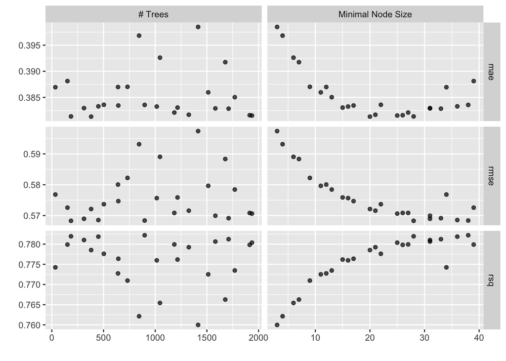

```r
# Define the search space
my.grid <- dials %>%
  update(trees = trees(c(1, 2000))) %>%
  grid_latin_hypercube(size = 25)
# Tune the model
model_params <-  tune_grid(
    wf_forest,
    resamples = camels_cv,
    grid = my.grid,
    metrics = metric_set(rmse, rsq, mae),
    control = control_grid(save_pred = TRUE)
  )

autoplot(model_params)
```

Looking at the plot, as minimal node size increases, so does RSQ but MAE and RMSE decrease.

```r
# Check the skill of the tuned model
tree_metrics = metric_set(rsq, rmse, mae)

hp_best <- select_best(model_params, metric = "mae")

wf_final <- finalize_workflow(wf_forest, hp_best)

final_fit <- last_fit(wf_final, camels_split, metrics = tree_metrics)

collect_metrics(final_fit)
```

```
# A tibble: 3 × 4
  .metric .estimator .estimate .config
  <chr>   <chr>          <dbl> <chr>
1 rsq     standard       0.805 Preprocessor1_Model1
2 rmse    standard       0.609 Preprocessor1_Model1
3 mae     standard       0.337 Preprocessor1_Model1
```

The estimates for RSQ, RMSE, and MAE are all standard. MAE is the lowest metric and RSQ is the highest metric, which indicates a strong correlation in the model. Low RMSE and MAE values mean there is a low prediction error.

```r
show_best(model_params, metric = "mae")
```

```
# A tibble: 5 × 8
  trees min_n .metric .estimator  mean     n std_err .config
  <int> <int> <chr>   <chr>      <dbl> <int>   <dbl> <chr>
1   380    20 mae     standard   0.381    10  0.0174 Preprocessor1_Model10
2   185    28 mae     standard   0.381    10  0.0169 Preprocessor1_Model22
3  1936    25 mae     standard   0.382    10  0.0176 Preprocessor1_Model11
4  1914    26 mae     standard   0.382    10  0.0173 Preprocessor1_Model17
5  1325    21 mae     standard   0.382    10  0.0179 Preprocessor1_Model12
```

Looking at the first row of `show_best`, model number 10 had 380 trees and 20 min_n returned a mean MAE of 0.38.

```r
hp_best <- select_best(model_params, metric = "mae")

# Finalize the model
final <- finalize_workflow(wf_forest, hp_best)
```